# **AIML Module Project - Supervised Learning** - Total Score 60

# Part A - 30 Marks

**• DOMAIN:** Medical

**• CONTEXT:** Medical research university X is undergoing a deep research on patients with certain conditions. University has an internal AI team. Due to confidentiality the patient’s details and the conditions are masked by the client by providing different datasets to the AI team for developing a AIML model which can predict the condition of the patient depending on the received test results.

**• DATA DESCRIPTION:** The data consists of biomechanics features of the patients according to their current conditions. Each patient is represented in the data set by six biomechanics attributes derived from the shape and orientation of the condition to their body part.

**• PROJECT OBJECTIVE:** To Demonstrate the ability to fetch, process and leverage data to generate useful predictions by training Supervised Learning algorithms.

## STEPS AND TASK [30 Marks]:

### 1. Data Understanding: [5 Marks]

```python
#importing necessary libraries
import pandas as pd
import numpy as np
```

#### A. Read all the 3 CSV files as DataFrame and store them into 3 separate variables. [1 Mark]

```python
# Read data and check for first 5 rows
normal = pd.read_csv('normal.csv')
normal.head(5)
```

|  | P_incidence | P_tilt | L_angle | S_slope | P_radius | S_Degree | Class |
| --- | --- | --- | --- | --- | --- | --- | --- |
| 0 | 38.505273 | 16.964297 | 35.112814 | 21.540976 | 127.632875 | 7.986683 | Normal |
| 1 | 54.920858 | 18.968430 | 51.601455 | 35.952428 | 125.846646 | 2.001642 | Normal |
| 2 | 44.362490 | 8.945435 | 46.902096 | 35.417055 | 129.220682 | 4.994195 | Normal |
| 3 | 48.318931 | 17.452121 | 48.000000 | 30.866809 | 128.980308 | -0.910941 | Normal |
| 4 | 45.701789 | 10.659859 | 42.577846 | 35.041929 | 130.178314 | -3.388910 | Normal |

```python
# Read data and check for first 5 rows
Type_H = pd.read_csv('Type_H.csv')
Type_H.head(5)
```

|  | P_incidence | P_tilt | L_angle | S_slope | P_radius | S_Degree | Class |
| --- | --- | --- | --- | --- | --- | --- | --- |
| 0 | 63.027817 | 22.552586 | 39.609117 | 40.475232 | 98.672917 | -0.254400 | Type_H |
| 1 | 39.056951 | 10.060991 | 25.015378 | 28.995960 | 114.405425 | 4.564259 | Type_H |
| 2 | 68.832021 | 22.218482 | 50.092194 | 46.613539 | 105.985135 | -3.530317 | Type_H |
| 3 | 69.297008 | 24.652878 | 44.311238 | 44.644130 | 101.868495 | 11.211523 | Type_H |
| 4 | 49.712859 | 9.652075 | 28.317406 | 40.060784 | 108.168725 | 7.918501 | Type_H |

```python
# Read data and check for first 5 rows
Type_S = pd.read_csv('Type_S.csv')
Type_S.head(5)
```

|  | P_incidence | P_tilt | L_angle | S_slope | P_radius | S_Degree | Class |
| --- | --- | --- | --- | --- | --- | --- | --- |
| 0 | 74.377678 | 32.053104 | 78.772013 | 42.324573 | 143.560690 | 56.125906 | Type_S |
| 1 | 89.680567 | 32.704435 | 83.130732 | 56.976132 | 129.955476 | 92.027277 | Type_S |
| 2 | 44.529051 | 9.433234 | 52.000000 | 35.095817 | 134.711772 | 29.106575 | Type_S |
| 3 | 77.690577 | 21.380645 | 64.429442 | 56.309932 | 114.818751 | 26.931841 | Type_S |
| 4 | 76.147212 | 21.936186 | 82.961502 | 54.211027 | 123.932010 | 10.431972 | Type_S |

#### B. Print Shape and columns of all the 3 DataFrames. [1 Mark]

```python
normal.shape
```

```
(100, 7)
```

```python
normal.columns
```

```
Index(['P_incidence', 'P_tilt', 'L_angle', 'S_slope', 'P_radius', 'S_Degree',
       'Class'],
      dtype='object')
```

```python
normal.info()
```

```
<class 'pandas.core.frame.DataFrame'>
RangeIndex: 100 entries, 0 to 99
Data columns (total 7 columns):
 #   Column       Non-Null Count  Dtype
---  ------       --------------  -----
 0   P_incidence  100 non-null    float64
 1   P_tilt       100 non-null    float64
 2   L_angle      100 non-null    float64
 3   S_slope      100 non-null    float64
 4   P_radius     100 non-null    float64
 5   S_Degree     100 non-null    float64
 6   Class        100 non-null    object
dtypes: float64(6), object(1)
memory usage: 5.6+ KB
```

```python
Type_H.shape
```

```
(60, 7)
```

```python
Type_H.columns
```

```
Index(['P_incidence', 'P_tilt', 'L_angle', 'S_slope', 'P_radius', 'S_Degree',
       'Class'],
      dtype='object')
```

```python
Type_H.info()
```

```
<class 'pandas.core.frame.DataFrame'>
RangeIndex: 60 entries, 0 to 59
Data columns (total 7 columns):
 #   Column       Non-Null Count  Dtype
---  ------       --------------  -----
 0   P_incidence  60 non-null     float64
 1   P_tilt       60 non-null     float64
 2   L_angle      60 non-null     float64
 3   S_slope      60 non-null     float64
 4   P_radius     60 non-null     float64
 5   S_Degree     60 non-null     float64
 6   Class        60 non-null     object
dtypes: float64(6), object(1)
memory usage: 3.4+ KB
```

```python
Type_S.shape
```

```
(150, 7)
```

```python
Type_S.columns
```

```
Index(['P_incidence', 'P_tilt', 'L_angle', 'S_slope', 'P_radius', 'S_Degree',
       'Class'],
      dtype='object')
```

```python
Type_S.info()
```

```
<class 'pandas.core.frame.DataFrame'>
RangeIndex: 150 entries, 0 to 149
Data columns (total 7 columns):
 #   Column       Non-Null Count  Dtype
---  ------       --------------  -----
 0   P_incidence  150 non-null    float64
 1   P_tilt       150 non-null    float64
 2   L_angle      150 non-null    float64
 3   S_slope      150 non-null    float64
 4   P_radius     150 non-null    float64
 5   S_Degree     150 non-null    float64
 6   Class        150 non-null    object
dtypes: float64(6), object(1)
memory usage: 8.3+ KB
```

#### D. Print DataTypes of all the 3 DataFrames. [1 Mark]

```python
# check datatypes
normal.dtypes
```

```
P_incidence    float64
P_tilt         float64
L_angle        float64
S_slope        float64
P_radius       float64
S_Degree       float64
Class           object
dtype: object
```

```python
# check datatypes
Type_S.dtypes
```

```
P_incidence    float64
P_tilt         float64
L_angle        float64
S_slope        float64
P_radius       float64
S_Degree       float64
Class           object
dtype: object
```

```python
# check datatypes
Type_H.dtypes
```

```
P_incidence    float64
P_tilt         float64
L_angle        float64
S_slope        float64
P_radius       float64
S_Degree       float64
Class           object
dtype: object
```

#### E. Observe and share variation in ‘Class’ feature of all the 3 DaraFrames. [1 Mark]

```python
normal['Class'].value_counts()
```

```
Normal    73
Nrmal     27
Name: Class, dtype: int64
```

```python
Type_H['Class'].value_counts()
```

```
Type_H    37
type_h    23
Name: Class, dtype: int64
```

```python
Type_S['Class'].value_counts()
```

```
Type_S    133
tp_s       17
Name: Class, dtype: int64
```

We could observe that normal dataframe has distinct Class values 'Normal' and 'Nrmal', similarly Type_H has 'Type_H' and 'type_h', and similarly Type_S has 'Type_S' and 'tp_s'

### 2. Data Preparation and Exploration: [5 Marks]

#### A. Unify all the variations in ‘Class’ feature for all the 3 DataFrames. [1 Marks]

For Example: ‘tp_s’, ‘Type_S’, ‘type_s’ should be converted to ‘type_s’

```python
normal['Class'].replace('Normal','normal',inplace=True)
normal['Class'].replace('Nrmal','normal',inplace=True)
normal['Class'].value_counts()
```

```
normal    100
Name: Class, dtype: int64
```

```python
Type_H['Class'].replace('Type_H','type_h',inplace=True)
Type_H['Class'].value_counts()
```

```
type_h    60
Name: Class, dtype: int64
```

```python
Type_S['Class'].replace('Type_S','type_s',inplace=True)
Type_S['Class'].replace('tp_s','type_s',inplace=True)
Type_S['Class'].value_counts()
```

```
type_s    150
Name: Class, dtype: int64
```

#### B. Combine all the 3 DataFrames to form a single DataFrame [1 Marks]

Checkpoint: Expected Output shape = (310,7)

```python
combined_df = pd.concat([normal,Type_S,Type_H])
combined_df = combined_df.reset_index(drop=True)
combined_df.shape
```

```
(310, 7)
```

#### C. Print 5 random samples of this DataFrame [1 Marks]

```python
combined_df.sample(n=5)
```

|  | P_incidence | P_tilt | L_angle | S_slope | P_radius | S_Degree | Class |
| --- | --- | --- | --- | --- | --- | --- | --- |
| 124 | 76.326002 | 42.396204 | 57.200000 | 33.929797 | 124.267007 | 50.127457 | type_s |
| 254 | 49.712859 | 9.652075 | 28.317406 | 40.060784 | 108.168725 | 7.918501 | type_h |
| 51 | 74.976021 | 14.921705 | 53.730072 | 60.054317 | 105.645400 | 1.594748 | normal |
| 275 | 54.124920 | 26.650489 | 35.329747 | 27.474432 | 121.447011 | 1.571205 | type_h |
| 272 | 63.073611 | 24.413803 | 54.000000 | 38.659808 | 106.424329 | 15.779697 | type_h |

#### D. Print Feature-wise percentage of Null values. [1 Mark]

```python
combined_df.isnull().sum() * 100 / len(combined_df)
```

```
P_incidence    0.0
P_tilt         0.0
L_angle        0.0
S_slope        0.0
P_radius       0.0
S_Degree       0.0
Class          0.0
dtype: float64
```

Observation: There are no null values in any of the attributes in the combined dataframe

#### E. Check 5-point summary of the new DataFrame. [1 Mark]

```python
combined_df.describe(include='all').T
```

|  | count | unique | top | freq | mean | std | min | 25% | 50% | 75% | max |
| --- | --- | --- | --- | --- | --- | --- | --- | --- | --- | --- | --- |
| P_incidence | 310.0 | NaN | NaN | NaN | 60.496653 | 17.23652 | 26.147921 | 46.430294 | 58.691038 | 72.877696 | 129.834041 |
| P_tilt | 310.0 | NaN | NaN | NaN | 17.542822 | 10.00833 | -6.554948 | 10.667069 | 16.357689 | 22.120395 | 49.431864 |
| L_angle | 310.0 | NaN | NaN | NaN | 51.93093 | 18.554064 | 14.0 | 37.0 | 49.562398 | 63.0 | 125.742385 |
| S_slope | 310.0 | NaN | NaN | NaN | 42.953831 | 13.423102 | 13.366931 | 33.347122 | 42.404912 | 52.695888 | 121.429566 |
| P_radius | 310.0 | NaN | NaN | NaN | 117.920655 | 13.317377 | 70.082575 | 110.709196 | 118.268178 | 125.467674 | 163.071041 |
| S_Degree | 310.0 | NaN | NaN | NaN | 26.296694 | 37.559027 | -11.058179 | 1.603727 | 11.767934 | 41.287352 | 418.543082 |
| Class | 310 | 3 | type_s | 150 | NaN | NaN | NaN | NaN | NaN | NaN | NaN |

### 3. Data Analysis: [10 Marks]

```python
import matplotlib.pyplot as plt       # matplotlib.pyplot plots data
%matplotlib inline
import seaborn as sns
```

#### A. Visualize a heatmap to understand correlation between all features [2 Marks]

```python
combined_df.corr()
```

|  | P_incidence | P_tilt | L_angle | S_slope | P_radius | S_Degree |
| --- | --- | --- | --- | --- | --- | --- |
| P_incidence | 1.000000 | 0.629199 | 0.717282 | 0.814960 | -0.247467 | 0.638743 |
| P_tilt | 0.629199 | 1.000000 | 0.432764 | 0.062345 | 0.032668 | 0.397862 |
| L_angle | 0.717282 | 0.432764 | 1.000000 | 0.598387 | -0.080344 | 0.533667 |
| S_slope | 0.814960 | 0.062345 | 0.598387 | 1.000000 | -0.342128 | 0.523557 |
| P_radius | -0.247467 | 0.032668 | -0.080344 | -0.342128 | 1.000000 | -0.026065 |
| S_Degree | 0.638743 | 0.397862 | 0.533667 | 0.523557 | -0.026065 | 1.000000 |

```python
def plot_corr(combined_df, size=6):
    corr = combined_df.corr()
    fig, ax = plt.subplots(figsize=(size, size))
    #ax.matshow(corr)
    sns.heatmap(corr, annot=True)
    plt.xticks(range(len(corr.columns)), corr.columns)
    plt.yticks(range(len(corr.columns)), corr.columns)
```

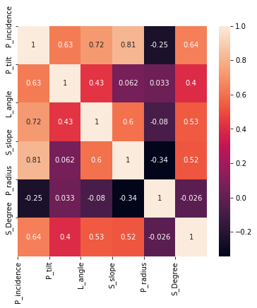

```python
plot_corr(combined_df)
```

#### B. Share insights on correlation. [2 Marks]

##### A. Features having stronger correlation with correlation value.

##### B. Features having weaker correlation with correlation value.

A strong positive correlation of 0.81 between P_incidence and S_slopes.

No Strong negative correlation between any variables.

Weaker correlation of -0.026 between P_radius and S_Degree. And, 0.033 between P_tilt and P_radius.

#### C. Visualize a pairplot with 3 classes distinguished by colors and share insights. [2 Marks]

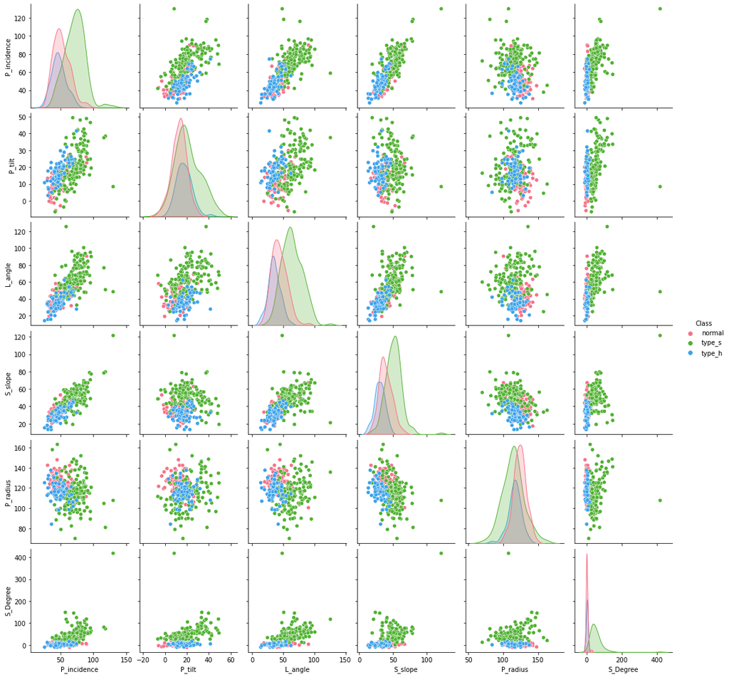

```python
sns.pairplot(combined_df, hue = "Class", palette="husl");
```

From this pair plot we could infere that

P_incidence and P_tilt, P_incidence and L_angle, P_incidence and S_slope, P_tilt and L_angle, L_angle and S_slope has linear relationship and they are positively correlated.

Volume of type_s is higher compared to type_h and normal.

We could observe that, class type_s has more spread.

type_h class is covered by type_s and normal and only in S_slope there is some variation in type_h.

P_tilt and P_radius, P_radius and P_slope has no correlation, no linear relation and they are spread throught.

normal class is constant throught S_Degree.

#### D. Visualize a jointplot for ‘P_incidence’ and ‘S_slope’ and share insights. [2 Marks]

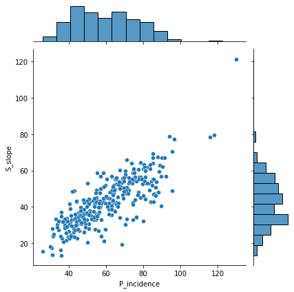

```python
sns.jointplot(combined_df['P_incidence'], combined_df['S_slope']);
```

S_slope and P_incidence has linear relationship and they have strong positive correlation

S_slope and P_incidence is right-skewed

#### E. Visualize a boxplot to check distribution of the features and share insights. [2 Marks]

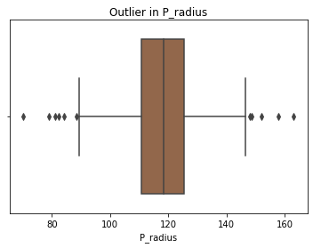

```python
sns.boxplot(combined_df['P_radius'],palette = 'copper').set_title('Outlier in P_radius')
```

We can interpret that P_radius is normally distributed

Outliers are present in both lower and upper fence.

Number of outliers in Lower fence > no. of outliers in Upper fence

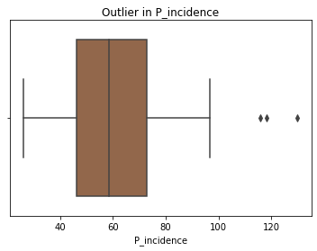

```python
sns.boxplot(combined_df['P_incidence'],palette = 'copper').set_title('Outlier in P_incidence')
```

We can interpret that P_incidence is right skewed.

Outliers are present only in upper fence.

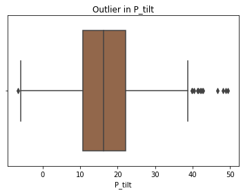

```python
sns.boxplot(combined_df['P_tilt'],palette = 'copper').set_title('Outlier in P_tilt')
```

We can interpret that P_tilt is right skewed.

Outliers are present in both lower and upper fence.

Number of outliers in Lower fence < no. of outliers in Upper fence. Only one outlier is present in Lower fence.

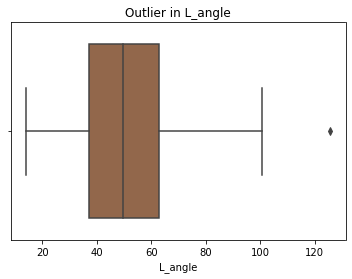

```python
sns.boxplot(combined_df['L_angle'],palette = 'copper').set_title('Outlier in L_angle')
```

We can interpret that L_angle is right skewed.

Outliers are present only in upper fence.

Only one outlier is present in upper fence.

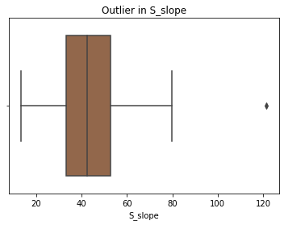

```python
sns.boxplot(combined_df['S_slope'],palette = 'copper').set_title('Outlier in S_slope')
```

We can interpret that S_slope is right skewed.

Outliers are present only in upper fence.

Only one outlier is present in upper fence.

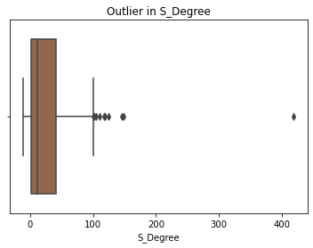

```python
sns.boxplot(combined_df['S_Degree'],palette = 'copper').set_title('Outlier in S_Degree')
```

We can interpret that S_Degree is right-skewed.

Outliers are present only in upper fence.

One outlier is in the extreme right region with S_Degree > 400

### 4. Model Building: [6 Marks]

```python
# To enable plotting graphs in Jupyter notebook
from sklearn.model_selection import train_test_split
from sklearn.neighbors import KNeighborsClassifier
from scipy.stats import zscore
```

#### A. Split data into X and Y. [1 Marks]

```python
# Create a separate dataframe consisting only of the features i.e independent attributes

X = combined_df.drop(labels= "Class" , axis = 1)
Y = combined_df["Class"]
X.head()
```

|  | P_incidence | P_tilt | L_angle | S_slope | P_radius | S_Degree |
| --- | --- | --- | --- | --- | --- | --- |
| 0 | 38.505273 | 16.964297 | 35.112814 | 21.540976 | 127.632875 | 7.986683 |
| 1 | 54.920858 | 18.968430 | 51.601455 | 35.952428 | 125.846646 | 2.001642 |
| 2 | 44.362490 | 8.945435 | 46.902096 | 35.417055 | 129.220682 | 4.994195 |
| 3 | 48.318931 | 17.452121 | 48.000000 | 30.866809 | 128.980308 | -0.910941 |
| 4 | 45.701789 | 10.659859 | 42.577846 | 35.041929 | 130.178314 | -3.388910 |

```python
# convert the features into z scores as we do not know what units / scales were used and store them in new dataframe
# It is always adviced to scale numeric attributes in models that calculate distances.

XScaled  = X.apply(zscore)  # convert all attributes to Z scale

XScaled.describe()
```

|  | P_incidence | P_tilt | L_angle | S_slope | P_radius | S_Degree |
| --- | --- | --- | --- | --- | --- | --- |
| count | 3.100000e+02 | 3.100000e+02 | 3.100000e+02 | 3.100000e+02 | 3.100000e+02 | 3.100000e+02 |
| mean | -8.559461e-17 | 2.222237e-16 | 3.137275e-16 | -1.493429e-16 | -5.624533e-16 | -5.228792e-17 |
| std | 1.001617e+00 | 1.001617e+00 | 1.001617e+00 | 1.001617e+00 | 1.001617e+00 | 1.001617e+00 |
| min | -1.996010e+00 | -2.411664e+00 | -2.047652e+00 | -2.207741e+00 | -3.597963e+00 | -9.961725e-01 |
| 25% | -8.173982e-01 | -6.881138e-01 | -8.060267e-01 | -7.168418e-01 | -5.423830e-01 | -6.585073e-01 |
| 50% | -1.049246e-01 | -1.186061e-01 | -1.278621e-01 | -4.095971e-02 | 2.613767e-02 | -3.874502e-01 |
| 75% | 7.194643e-01 | 4.581158e-01 | 5.975493e-01 | 7.269414e-01 | 5.676209e-01 | 3.997679e-01 |
| max | 4.029206e+00 | 3.191402e+00 | 3.984615e+00 | 5.855771e+00 | 3.395818e+00 | 1.046035e+01 |

#### B. Split data into train and test with 80:20 proportion. [1 Marks]

```python
# Split X and y into training and test set in 75:25 ratio

X_train, X_test, Y_train, Y_test = train_test_split(XScaled, Y, test_size=0.20, random_state=1)
```

```python
print("{0:0.2f}% data is in training set".format((len(X_train)/len(combined_df.index)) * 100))
print("{0:0.2f}% data is in test set".format((len(X_test)/len(combined_df.index)) * 100))
```

```
80.00% data is in training set
20.00% data is in test set
```

#### C. Train a Supervised Learning Classification base model using KNN classifier. [2 Marks]

KNN Model is best suitable for multiclass classification

```python
knn = KNeighborsClassifier()

# Call Nearest Neighbour algorithm

knn.fit(X_train, Y_train)

# For every test data point, predict it's label based on 5 nearest neighbours in this model. The majority class will
# be assigned to the test data point

predicted_labels = knn.predict(X_test)
knn.score(X_test, Y_test)
```

```
0.7419354838709677
```

```
Confusion Matrix
```

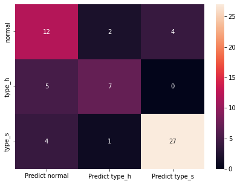

```python
# calculate accuracy measures and confusion matrix
from sklearn import metrics

print("Confusion Matrix")
cm=metrics.confusion_matrix(Y_test, predicted_labels, labels=["normal", "type_h", "type_s"])

df_cm = pd.DataFrame(cm, index = [i for i in ["normal", "type_h", "type_s"]],
                  columns = [i for i in ["Predict normal","Predict type_h","Predict type_s"]])
plt.figure(figsize = (7,5))
sns.heatmap(df_cm, annot=True)
```

#### D. Print all the possible performance metrics for both train and test data. [2 Marks]

```python
from sklearn.metrics import precision_score
from sklearn.metrics import recall_score
from sklearn.metrics import accuracy_score
from sklearn.metrics import roc_auc_score
from sklearn.model_selection import GridSearchCV
```

```python
predicted_labels_train = knn.predict(X_train)
knn.score(X_train, Y_train)
```

```
0.842741935483871
```

```python
Precision_ini_train =precision_score(Y_train, predicted_labels_train, average='weighted')
print("Training Precision:{0:.4f}".format(Precision_ini_train))
Recall_ini_train =recall_score(Y_train, predicted_labels_train, average='weighted')
print("Training Recall:{0:.4f}".format(Recall_ini_train))
Accuracy_ini_train =accuracy_score(Y_train, predicted_labels_train)
print("Training Accuracy:{0:.4f}".format(Accuracy_ini_train))
```

```
Training Precision:0.8479
Training Recall:0.8427
Training Accuracy:0.8427
```

```python
print("Classification Report")
print(metrics.classification_report(Y_train, predicted_labels_train, labels=["normal", "type_h", "type_s"]))
```

```
Classification Report
              precision    recall  f1-score   support

      normal       0.78      0.80      0.79        82
      type_h       0.71      0.75      0.73        48
      type_s       0.96      0.91      0.93       118

    accuracy                           0.84       248
   macro avg       0.81      0.82      0.82       248
weighted avg       0.85      0.84      0.84       248
```

```python
Precision_ini =precision_score(Y_test, predicted_labels, average='weighted')
print("Precision_test:{0:.4f}".format(Precision_ini))
Recall_ini =recall_score(Y_test, predicted_labels, average='weighted')
print("Recall_test:{0:.4f}".format(Recall_ini))
Accuracy_ini =accuracy_score(Y_test, predicted_labels)
print("Accuracy_test:{0:.4f}".format(Accuracy_ini))
```

```
Precision_test:0.7509
Recall_test:0.7419
Accuracy_test:0.7419
```

```python
print("Classification Report")
print(metrics.classification_report(Y_test, predicted_labels, labels=["normal", "type_h", "type_s"]))
```

```
Classification Report
              precision    recall  f1-score   support

      normal       0.57      0.67      0.62        18
      type_h       0.70      0.58      0.64        12
      type_s       0.87      0.84      0.86        32

    accuracy                           0.74        62
   macro avg       0.71      0.70      0.70        62
weighted avg       0.75      0.74      0.74        62
```

From the classification report, it can be seen that the model has an average performance of around 74% ranging from precision, recall, f1-score, and support in Test data. Accuracy also shows in value of 74%. Whereas in Train data, accuracy is around 84%

### 5. Performance Improvement: [4 Marks]

#### A. Experiment with various parameters to improve performance of the base model. [2 Marks]

##### (Optional: Experiment with various Hyperparameters - Research required)

```python
# instantiate learning model(k=3)
knn = KNeighborsClassifier(n_neighbors = 3)

# Call Nearest Neighbour algorithm

knn.fit(X_train, Y_train)

# For every test data point, predict it's label based on 5 nearest neighbours in this model. The majority class will
# be assigned to the test data point

predicted_labels = knn.predict(X_test)

#Evaluate Accuracy
print("Accuracy when k=3: {0:.4f}".format(accuracy_score(Y_test,predicted_labels)))

# instantiate learning model(k=5)
knn = KNeighborsClassifier(n_neighbors = 5)

# Call Nearest Neighbour algorithm

knn.fit(X_train, Y_train)

# For every test data point, predict it's label based on 5 nearest neighbours in this model. The majority class will
# be assigned to the test data point

predicted_labels = knn.predict(X_test)

#Evaluate Accuracy
print("Accuracy when k=5: {0:.4f}".format(accuracy_score(Y_test,predicted_labels)))

# instantiate learning model(k=9)
knn = KNeighborsClassifier(n_neighbors = 9)

# Call Nearest Neighbour algorithm

knn.fit(X_train, Y_train)

# For every test data point, predict it's label based on 5 nearest neighbours in this model. The majority class will
# be assigned to the test data point

predicted_labels = knn.predict(X_test)

#Evaluate Accuracy
print("Accuracy when k=9: {0:.4f}".format(accuracy_score(Y_test,predicted_labels)))
```

```
Accuracy when k=3: 0.7258
Accuracy when k=5: 0.7419
Accuracy when k=9: 0.7419
```

```python
#List Hyperparameters that we want to tune.
leaf_size = list(range(1,5))
n_neighbors = list(range(1,5))
p=[1,2]

#Convert to dictionary
hyperparameters = dict(leaf_size=leaf_size, n_neighbors=n_neighbors, p=p)

#Create new KNN object
knn_2 = KNeighborsClassifier()

#Use GridSearch
clf = GridSearchCV(knn_2, hyperparameters, cv=20)

#Fit the model
best_model = clf.fit(X,Y)

#Print The value of best Hyperparameters
print('Best leaf_size:', best_model.best_estimator_.get_params()['leaf_size'])
print('Best p:', best_model.best_estimator_.get_params()['p'])
print('Best n_neighbors:', best_model.best_estimator_.get_params()['n_neighbors'])
```

```
Best leaf_size: 1
Best p: 2
Best n_neighbors: 1
```

```python
# creating odd list of K for KNN
myList = list(range(1,20))

# subsetting just the odd ones
neighbors = list(filter(lambda x: x % 2 != 0, myList))

# empty list that will hold accuracy scores
ac_scores = []

# perform accuracy metrics for values from 1,3,5....19
for k in neighbors:
    knn = KNeighborsClassifier(n_neighbors=k)
    knn.fit(X_train, Y_train)
    # predict the response
    y_pred = knn.predict(X_test)
    # evaluate accuracy
    scores = accuracy_score(Y_test, y_pred)
    ac_scores.append(scores)

# changing to misclassification error
MSE = [1 - x for x in ac_scores]

# determining best k
optimal_k = neighbors[MSE.index(min(MSE))]
print("The optimal number of neighbors is %d" % optimal_k)
```

```
The optimal number of neighbors is 1
```

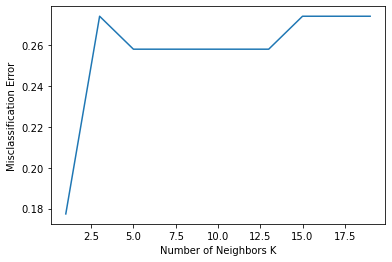

```python
#Plot misclassification error vs k (with k value on X-axis) using matplotlib.

import matplotlib.pyplot as plt
# plot misclassification error vs k
plt.plot(neighbors, MSE)
plt.xlabel('Number of Neighbors K')
plt.ylabel('Misclassification Error')
plt.show()
```

Thus when number of Neighbors is low the misclassification error is also lower

```python
# Split X and y into training and test set in 80:20 ratio
X_train, X_test, Y_train, Y_test = train_test_split(XScaled, Y, test_size=0.20, random_state=1)

NNH = KNeighborsClassifier(n_neighbors= 1, p = 2, leaf_size = 1)

# Call Nearest Neighbour algorithm
NNH.fit(X_train, Y_train)

# For every test data point, predict it's label based on 1 nearest neighbours in this model. The majority class will # be assigned to the test data point
predicted_labels = NNH.predict(X_test)
NNH.score(X_test, Y_test)
```

```
0.8225806451612904
```

```
Confusion Matrix
```

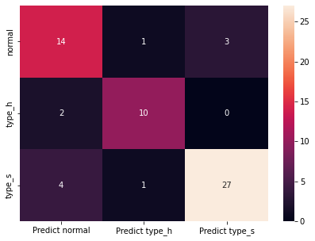

```python
# calculate accuracy measures and confusion matrix
from sklearn import metrics

print("Confusion Matrix")
cm=metrics.confusion_matrix(Y_test, predicted_labels, labels=["normal", "type_h", "type_s"])

df_cm = pd.DataFrame(cm, index = [i for i in ["normal", "type_h", "type_s"]],
                  columns = [i for i in ["Predict normal","Predict type_h","Predict type_s"]])
plt.figure(figsize = (7,5))
sns.heatmap(df_cm, annot=True)
```

```python
print("Classification Report")
print(metrics.classification_report(Y_test, predicted_labels, labels=["normal", "type_h", "type_s"]))
```

```
Classification Report
              precision    recall  f1-score   support

      normal       0.70      0.78      0.74        18
      type_h       0.83      0.83      0.83        12
      type_s       0.90      0.84      0.87        32

    accuracy                           0.82        62
   macro avg       0.81      0.82      0.81        62
weighted avg       0.83      0.82      0.82        62
```

#### B. Clearly showcase improvement in performance achieved. [1 Marks]

##### For Example:

##### A. Accuracy: +15% improvement

##### B. Precision: +10% improvement.

```python
Precision_k1 = precision_score(Y_test, predicted_labels, average='weighted')
print("Precision when n_neighbors= 1, p = 2, leaf_size = 1: {0:.4f}".format(Precision_k1))
Recall_k1 = recall_score(Y_test, predicted_labels, average='weighted')
print("Recall when n_neighbors= 1, p = 2, leaf_size = 1: {0:.4f}".format(Recall_k1))
Accuracy_k1 = accuracy_score(Y_test, predicted_labels)
print("Accuracy when n_neighbors= 1, p = 2, leaf_size = 1: {0:.4f}".format(Accuracy_k1))
```

```
Precision when n_neighbors= 1, p = 2, leaf_size = 1: 0.8290
Recall when n_neighbors= 1, p = 2, leaf_size = 1: 0.8226
Accuracy when n_neighbors= 1, p = 2, leaf_size = 1: 0.8226
```

```python
# Accuracy improved:
print("Accuracy Improved in %: {0:.2f}".format((Accuracy_k1-Accuracy_ini)/Accuracy_k1 * 100))
# Precision improved:
print("Precision Improved in %: {0:.2f}".format((Precision_k1-Precision_ini)/Precision_k1 * 100))
# Recall improved:
print("Recall Improved in %: {0:.2f}".format((Recall_k1-Recall_ini)/Recall_k1 * 100))
```

```
Accuracy Improved in %: 9.80
Precision Improved in %: 9.42
Recall Improved in %: 9.80
```

#### C. Clearly state which parameters contributed most to improve model performance. [1 Marks]

From GridSearch, it can be seen that the best number of leaf_size is 1 while the optimal distance method is Euclidean or p = 2

**Then the most optimal number of K is 1 and this contributed the most to improve performance as when K is more the accuracy, precision, recall, f1-score were less**

Using Hyperparameters Tuning can **improve model performance by about 10%** to a range of 82% for all evaluation matrices.

# Part B - 30 Marks

**• DOMAIN:** Banking, Marketing

**• CONTEXT:** A bank X is on a massive digital transformation for all its departments. Bank has a growing customer base whee majority of them are liability customers (depositors) vs borrowers (asset customers). The bank is interested in expanding the borrowers base rapidly to bring in more business via loan interests. A campaign that the bank ran in last quarter showed an average single digit conversion rate. Digital transformation being the core strength of the business strategy, marketing department wants to devise effective campaigns with better target marketing to increase the conversion ratio to double digit with same budget as per last campaign.

**• DATA DICTIONARY:**

1. Team: Team’s name
2. ID: Customer ID
3. Age: Customer’s approximate age.
4. CustomerSince: Customer of the bank since. [unit is masked]
5. HighestSpend: Customer’s highest spend so far in one transaction. [unit is masked]
6. ZipCode: Customer’s zip code.
7. HiddenScore: A score associated to the customer which is masked by the bank as an IP.
8. MonthlyAverageSpend: Customer’s monthly average spend so far. [unit is masked]
9. Level: A level associated to the customer which is masked by the bank as an IP.
10. Mortgage: Customer’s mortgage. [unit is masked]
11. Security: Customer’s security asset with the bank. [unit is masked]
12. FixedDepositAccount: Customer’s fixed deposit account with the bank. [unit is masked]
13. InternetBanking: if the customer uses internet banking.
14. CreditCard: if the customer uses bank’s credit card.
15. LoanOnCard: if the customer has a loan on credit card.

**• PROJECT OBJECTIVE:** Build a Machine Learning model to perform focused marketing by predicting the potential customers who will convert using the historical dataset.

## STEPS AND TASK [30 Marks]:

### 1. Data Understanding and Preparation: [5 Marks]

#### A. Read both the Datasets ‘Data1’ and ‘Data 2’ as DataFrame and store them into two separate variables. [1 Marks]

```python
# Read data and check for first 5 rows
Data1 = pd.read_csv('Data1.csv')
Data1.head(5)
```

|  | ID | Age | CustomerSince | HighestSpend | ZipCode | HiddenScore | MonthlyAverageSpend | Level |
| --- | --- | --- | --- | --- | --- | --- | --- | --- |
| 0 | 1 | 25 | 1 | 49 | 91107 | 4 | 1.6 | 1 |
| 1 | 2 | 45 | 19 | 34 | 90089 | 3 | 1.5 | 1 |
| 2 | 3 | 39 | 15 | 11 | 94720 | 1 | 1.0 | 1 |
| 3 | 4 | 35 | 9 | 100 | 94112 | 1 | 2.7 | 2 |
| 4 | 5 | 35 | 8 | 45 | 91330 | 4 | 1.0 | 2 |

```python
# Read data and check for first 5 rows
Data2 = pd.read_csv('Data2.csv')
Data2.head(5)
```

|  | ID | Mortgage | Security | FixedDepositAccount | InternetBanking | CreditCard | LoanOnCard |
| --- | --- | --- | --- | --- | --- | --- | --- |
| 0 | 1 | 0 | 1 | 0 | 0 | 0 | NaN |
| 1 | 2 | 0 | 1 | 0 | 0 | 0 | NaN |
| 2 | 3 | 0 | 0 | 0 | 0 | 0 | NaN |
| 3 | 4 | 0 | 0 | 0 | 0 | 0 | NaN |
| 4 | 5 | 0 | 0 | 0 | 0 | 1 | NaN |

#### B. Print shape and Column Names and DataTypes of both the Dataframes. [1 Marks]

```python
Data1.shape
```

```
(5000, 8)
```

```python
Data1.columns
```

```
Index(['ID', 'Age', 'CustomerSince', 'HighestSpend', 'ZipCode', 'HiddenScore',
       'MonthlyAverageSpend', 'Level'],
      dtype='object')
```

```python
Data1.dtypes
```

```
ID                       int64
Age                      int64
CustomerSince            int64
HighestSpend             int64
ZipCode                  int64
HiddenScore              int64
MonthlyAverageSpend    float64
Level                    int64
dtype: object
```

```python
Data2.shape
```

```
(5000, 7)
```

```python
Data2.columns
```

```
Index(['ID', 'Mortgage', 'Security', 'FixedDepositAccount', 'InternetBanking',
       'CreditCard', 'LoanOnCard'],
      dtype='object')
```

```python
Data2.dtypes
```

```
ID                       int64
Mortgage                 int64
Security                 int64
FixedDepositAccount      int64
InternetBanking          int64
CreditCard               int64
LoanOnCard             float64
dtype: object
```

#### C. Merge both the Dataframes on ‘ID’ feature to form a single DataFrame [2 Marks]

```python
Data = Data1.merge(Data2,how='inner', on = 'ID')
```

```python
Data.shape
```

```
(5000, 14)
```

```python
Data.head()
```

|  | ID | Age | CustomerSince | HighestSpend | ZipCode | HiddenScore | MonthlyAverageSpend | Level | Mortgage | Security | FixedDepositAccount | InternetBanking | CreditCard | LoanOnCard |
| --- | --- | --- | --- | --- | --- | --- | --- | --- | --- | --- | --- | --- | --- | --- |
| 0 | 1 | 25 | 1 | 49 | 91107 | 4 | 1.6 | 1 | 0 | 1 | 0 | 0 | 0 | NaN |
| 1 | 2 | 45 | 19 | 34 | 90089 | 3 | 1.5 | 1 | 0 | 1 | 0 | 0 | 0 | NaN |
| 2 | 3 | 39 | 15 | 11 | 94720 | 1 | 1.0 | 1 | 0 | 0 | 0 | 0 | 0 | NaN |
| 3 | 4 | 35 | 9 | 100 | 94112 | 1 | 2.7 | 2 | 0 | 0 | 0 | 0 | 0 | NaN |
| 4 | 5 | 35 | 8 | 45 | 91330 | 4 | 1.0 | 2 | 0 | 0 | 0 | 0 | 1 | NaN |

#### D. Change Datatype of below features to ‘Object’ [1 Marks]

##### ‘CreditCard’, ‘InternetBanking’, ‘FixedDepositAccount’, ‘Security’, ‘Level’, ‘HiddenScore’.

##### [Reason behind performing this operation:- Values in these features are binary i.e. 1/0. But DataType is ‘int’/’float’ which is not expected.]

```python
Data = Data.astype({"CreditCard":'object',"InternetBanking":'object',"FixedDepositAccount":'object',"Security":'object',
                    "Level":'object',"HiddenScore":'object'})
```

```python
Data.dtypes
```

```
ID                       int64
Age                      int64
CustomerSince            int64
HighestSpend             int64
ZipCode                  int64
HiddenScore             object
MonthlyAverageSpend    float64
Level                   object
Mortgage                 int64
Security                object
FixedDepositAccount     object
InternetBanking         object
CreditCard              object
LoanOnCard             float64
dtype: object
```

### 2. Data Exploration and Analysis: [5 Marks]

#### A. Visualize distribution of Target variable ‘LoanOnCard’ and clearly share insights. [2 Marks]

```python
Data['LoanOnCard'].value_counts()
```

```
0.0    4500
1.0     480
Name: LoanOnCard, dtype: int64
```

We could observe that the values in LoanOnCard feature is binary i.e. 1.0/0.0 and out of 5000 records about 4500 IDs has LoanOnCard as 0.0 and 480 IDs has 1.0 and for about 20 IDs the value of LoanOnCard is null.

#### B. Check the percentage of missing values and impute if required. [1 Marks]

```python
Data.isnull().sum()* 100 / len(Data)
```

```
ID                     0.0
Age                    0.0
CustomerSince          0.0
HighestSpend           0.0
ZipCode                0.0
HiddenScore            0.0
MonthlyAverageSpend    0.0
Level                  0.0
Mortgage               0.0
Security               0.0
FixedDepositAccount    0.0
InternetBanking        0.0
CreditCard             0.0
LoanOnCard             0.4
dtype: float64
```

Only LoanOnCard attribute contains Null, about 4500 IDs has LoanOnCard as 0.0 and 480 IDs has 1.0 and for about 20 IDs the value of LoanOnCard is null. Since, LoanOnCard is target variable it is better to drop all the records that contains null values in LoanOnCard column.

```python
Data = Data.dropna()
```

```python
Data.shape
```

```
(4980, 14)
```

```python
Data.isnull().sum() * 100 / len(Data)
```

```
ID                     0.0
Age                    0.0
CustomerSince          0.0
HighestSpend           0.0
ZipCode                0.0
HiddenScore            0.0
MonthlyAverageSpend    0.0
Level                  0.0
Mortgage               0.0
Security               0.0
FixedDepositAccount    0.0
InternetBanking        0.0
CreditCard             0.0
LoanOnCard             0.0
dtype: float64
```

Thus, the percentage of null became zero

#### C. Check for unexpected values in each categorical variable and impute with best suitable value. [2 Marks]

##### [Unexpected values means if all values in a feature are 0/1 then ‘?’, ‘a’, 1.5 are unexpected values which needs treatment ]

```python
Data['CreditCard'].value_counts()
```

```
0    3514
1    1466
Name: CreditCard, dtype: int64
```

```python
Data['CreditCard'].value_counts().sum()
```

```
4980
```

```python
Data['InternetBanking'].value_counts()
```

```
1    2974
0    2006
Name: InternetBanking, dtype: int64
```

```python
Data['InternetBanking'].value_counts().sum()
```

```
4980
```

```python
Data['FixedDepositAccount'].value_counts()
```

```
0    4678
1     302
Name: FixedDepositAccount, dtype: int64
```

```python
Data['FixedDepositAccount'].value_counts().sum()
```

```
4980
```

```python
Data['Security'].value_counts()
```

```
0    4460
1     520
Name: Security, dtype: int64
```

```python
Data['Security'].value_counts().sum()
```

```
4980
```

```python
Data['Level'].value_counts()
```

```
1    2089
3    1496
2    1395
Name: Level, dtype: int64
```

```python
Data['Level'].value_counts().sum()
```

```
4980
```

```python
Data['HiddenScore'].value_counts()
```

```
1    1466
2    1293
4    1215
3    1006
Name: HiddenScore, dtype: int64
```

```python
Data['HiddenScore'].value_counts().sum()
```

```
4980
```

All categorical fields does not have any unexpected values as the value counts looks perfect and the sum of the count is equal to 4980 which is the total number of records

### 3. Data Preparation and model building: [10 Marks]

#### A. Split data into X and Y. [1 Marks]

##### [Recommended to drop ID & ZipCode. LoanOnCard is target Variable]

```python
Data = Data.drop(labels= "ID" , axis = 1)
Data = Data.drop(labels= "ZipCode" , axis = 1)
```

```python
# Create a separate dataframe consisting only of the features i.e independent attributesD
x = Data.drop(labels= "LoanOnCard" , axis = 1)
y = Data["LoanOnCard"]
x.head()
```

|  | Age | CustomerSince | HighestSpend | HiddenScore | MonthlyAverageSpend | Level | Mortgage | Security | FixedDepositAccount | InternetBanking | CreditCard |
| --- | --- | --- | --- | --- | --- | --- | --- | --- | --- | --- | --- |
| 9 | 34 | 9 | 180 | 1 | 8.9 | 3 | 0 | 0 | 0 | 0 | 0 |
| 10 | 65 | 39 | 105 | 4 | 2.4 | 3 | 0 | 0 | 0 | 0 | 0 |
| 11 | 29 | 5 | 45 | 3 | 0.1 | 2 | 0 | 0 | 0 | 1 | 0 |
| 12 | 48 | 23 | 114 | 2 | 3.8 | 3 | 0 | 1 | 0 | 0 | 0 |
| 13 | 59 | 32 | 40 | 4 | 2.5 | 2 | 0 | 0 | 0 | 1 | 0 |

#### B. Split data into train and test. Keep 25% data reserved for testing. [1 Marks]

```python
# Split X and y into training and test set in 75:25 ratio

x_train, x_test, y_train, y_test = train_test_split(x, y, test_size=0.25, random_state=1)

x_train.head()
```

|  | Age | CustomerSince | HighestSpend | HiddenScore | MonthlyAverageSpend | Level | Mortgage | Security | FixedDepositAccount | InternetBanking | CreditCard |
| --- | --- | --- | --- | --- | --- | --- | --- | --- | --- | --- | --- |
| 3980 | 46 | 22 | 89 | 4 | 1.4 | 2 | 0 | 0 | 0 | 1 | 0 |
| 4489 | 39 | 13 | 21 | 3 | 0.2 | 2 | 0 | 0 | 0 | 1 | 0 |
| 4414 | 33 | 8 | 178 | 3 | 8.5 | 1 | 0 | 1 | 1 | 1 | 0 |
| 877 | 35 | 11 | 59 | 4 | 0.1 | 2 | 0 | 0 | 0 | 0 | 0 |
| 4390 | 52 | 26 | 62 | 4 | 2.8 | 2 | 0 | 0 | 0 | 1 | 0 |

```python
#We can see a lot of 0 entries above
from sklearn.impute import SimpleImputer
rep_0 = SimpleImputer(missing_values=0, strategy="mean")
x_train["CustomerSince"] = rep_0.fit_transform(x_train[["CustomerSince"]]).ravel()
x_train["Mortgage"] = rep_0.fit_transform(x_train[["Mortgage"]]).ravel()
x_train["Age"] = rep_0.fit_transform(x_train[["Age"]]).ravel()
x_train["HighestSpend"] = rep_0.fit_transform(x_train[["HighestSpend"]]).ravel()
x_train["MonthlyAverageSpend"] = rep_0.fit_transform(x_train[["MonthlyAverageSpend"]]).ravel()
x_train.head()
```

|  | Age | CustomerSince | HighestSpend | HiddenScore | MonthlyAverageSpend | Level | Mortgage | Security | FixedDepositAccount | InternetBanking | CreditCard |
| --- | --- | --- | --- | --- | --- | --- | --- | --- | --- | --- | --- |
| 3980 | 46.0 | 22.0 | 89.0 | 4 | 1.4 | 2 | 181.400347 | 0 | 0 | 1 | 0 |
| 4489 | 39.0 | 13.0 | 21.0 | 3 | 0.2 | 2 | 181.400347 | 0 | 0 | 1 | 0 |
| 4414 | 33.0 | 8.0 | 178.0 | 3 | 8.5 | 1 | 181.400347 | 1 | 1 | 1 | 0 |
| 877 | 35.0 | 11.0 | 59.0 | 4 | 0.1 | 2 | 181.400347 | 0 | 0 | 0 | 0 |
| 4390 | 52.0 | 26.0 | 62.0 | 4 | 2.8 | 2 | 181.400347 | 0 | 0 | 1 | 0 |

```python
print("{0:0.2f}% data is in training set".format((len(x_train)/len(Data.index)) * 100))
print("{0:0.2f}% data is in test set".format((len(x_test)/len(Data.index)) * 100))
```

```
75.00% data is in training set
25.00% data is in test set
```

#### C. Train a Supervised Learning Classification base model - Logistic Regression. [2 Marks]

```python
from sklearn.linear_model import LogisticRegression

# Fit the model on train
model = LogisticRegression(solver="liblinear")
model.fit(x_train, y_train)
#predict on test
y_predict = model.predict(x_test)


coef_df = pd.DataFrame(model.coef_)
coef_df['intercept'] = model.intercept_

print("Intercept: ",model.intercept_)
print("Coefficients are:")
print(model.coef_)
```

```
Intercept:  [-7.70112104]
Coefficients are:
[[-1.12405321e-01  1.08025682e-01  4.55292213e-02  4.65124396e-01
   7.89709075e-02  1.35780254e+00 -8.85907309e-04 -6.49939288e-01
   3.13270494e+00 -5.92423464e-01 -8.33802798e-01]]
```

These can be interpreted as -

The coefficents of Mortgage is very low, which indicates that the Mortgage does not really add to the odds of LoanOnCard

The intercept term -7.70 can be read as the value of log-odds when the dependent values tends to zero.

#### D. Print evaluation metrics for the model and clearly share insights. [1 Marks]

```python
model_score = model.score(x_test, y_test)
print(model_score)
```

```
0.9461847389558233
```

```python
# And some other metrics
print(metrics.classification_report(y_test, y_predict, digits=2))
```

```
              precision    recall  f1-score   support

         0.0       0.95      0.99      0.97      1118
         1.0       0.83      0.59      0.69       127

    accuracy                           0.95      1245
   macro avg       0.89      0.79      0.83      1245
weighted avg       0.94      0.95      0.94      1245
```

```python
Precision_b4_bal =precision_score(y_test, y_predict, average='weighted')
print("Precision before balancing:{0:.4f}".format(Precision_b4_bal))
Recall_b4_bal =recall_score(y_test, y_predict, average='weighted')
print("Recall before balancing:{0:.4f}".format(Recall_b4_bal))
Accuracy_b4_bal =accuracy_score(y_test, y_predict)
print("Accuracy before balancing:{0:.4f}".format(Accuracy_b4_bal))
```

```
Precision before balancing:0.9426
Recall before balancing:0.9462
Accuracy before balancing:0.9462
```

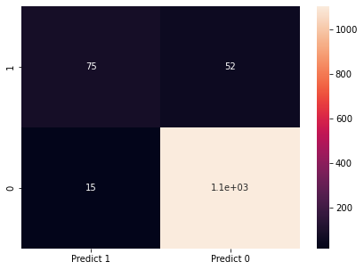

```python
cm=metrics.confusion_matrix(y_test, y_predict, labels=[1, 0])

df_cm = pd.DataFrame(cm, index = [i for i in ["1","0"]],
                  columns = [i for i in ["Predict 1","Predict 0"]])
plt.figure(figsize = (7,5))
sns.heatmap(df_cm, annot=True)
```

The confusion matrix

True Positives (TP): we correctly predicted that there is loan on card 75

True Negatives (TN): we correctly predicted that there is no loan on card 1103

False Positives (FP): we incorrectly predicted that there is loan on card (a "Type I error") 15 Falsely predict positive Type I error

False Negatives (FN): we incorrectly predicted that there is no loan on card (a "Type II error") 52 Falsely predict negative Type II error

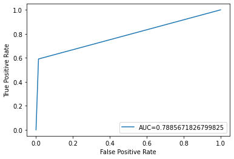

```python
# Calculate the AUC
fpr, tpr, _ = metrics.roc_curve(y_test,  y_predict)
auc_b4_bal = metrics.roc_auc_score(y_test, y_predict)

#create ROC curve
plt.plot(fpr,tpr,label="AUC="+str(auc_b4_bal))
plt.ylabel('True Positive Rate')
plt.xlabel('False Positive Rate')
plt.legend(loc=4)
plt.show()
```

The more that the curve hugs the top left corner of the plot, the better the model does at classifying the data into categories.

As we can see from the plot above, this logistic reg model does a average job of classifying the data into categories.

To quantify this, we can calculate the AUC – area under the curve – which tells us how much of the plot is located under the curve.

The closer AUC is to 1, the better the model. A model with an AUC equal to 0.5 is no better than a model that makes random classifications.

Thus, AUC = 0.78 is bit far from 1, which proves that this model is an average performing one for this case.

#### E. Balance the data using the right balancing technique. [2 Marks]

##### i. Check distribution of the target variable

##### ii. Say output is class A : 20% and class B : 80%

##### iii. Here you need to balance the target variable as 50:50.

##### iv. Try appropriate method to achieve the same.

```python
from collections import Counter
from sklearn.datasets import make_classification
from imblearn import under_sampling, over_sampling
from imblearn.over_sampling import SMOTE
from matplotlib import pyplot
from numpy import where
from imblearn.under_sampling import RandomUnderSampler
from imblearn.pipeline import Pipeline
```

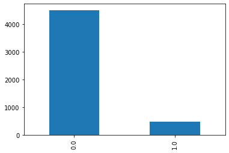

```python
y.value_counts().plot(kind='bar')
```

```python
Class_0 = y[y == 0].count()
Class_1 = y[y == 1].count()
Total_C = y.count()
```

```python
Class_0_p = Class_0 / Total_C * 100
print("LoanOnCard = 0 in percent is ", Class_0_p)
Class_1_p = Class_1/Total_C * 100
print("LoanOnCard = 1 in percent is ", Class_1_p)
```

```
LoanOnCard = 0 in percent is  90.36144578313254
LoanOnCard = 1 in percent is  9.63855421686747
```

```python
# Create a separate dataframe consisting only of the features i.e independent attributesD
x = Data.drop(labels= "LoanOnCard" , axis = 1)
y = Data["LoanOnCard"]
x.head()
```

|  | Age | CustomerSince | HighestSpend | HiddenScore | MonthlyAverageSpend | Level | Mortgage | Security | FixedDepositAccount | InternetBanking | CreditCard |
| --- | --- | --- | --- | --- | --- | --- | --- | --- | --- | --- | --- |
| 9 | 34 | 9 | 180 | 1 | 8.9 | 3 | 0 | 0 | 0 | 0 | 0 |
| 10 | 65 | 39 | 105 | 4 | 2.4 | 3 | 0 | 0 | 0 | 0 | 0 |
| 11 | 29 | 5 | 45 | 3 | 0.1 | 2 | 0 | 0 | 0 | 1 | 0 |
| 12 | 48 | 23 | 114 | 2 | 3.8 | 3 | 0 | 1 | 0 | 0 | 0 |
| 13 | 59 | 32 | 40 | 4 | 2.5 | 2 | 0 | 0 | 0 | 1 | 0 |

```python
counter = Counter(y)
print(counter)

# define pipeline
over = SMOTE(sampling_strategy=1)
under = RandomUnderSampler(sampling_strategy=1)
steps = [('o', over), ('u', under)]
pipeline = Pipeline(steps=steps)
# transform the dataset
x, y = pipeline.fit_resample(x, y)

counter = Counter(y)
print(counter)
```

```
Counter({0.0: 4500, 1.0: 480})
Counter({0.0: 4500, 1.0: 4500})
```

```python
# Split X and y into training and test set in 75:25 ratio

x_train, x_test, y_train, y_test = train_test_split(x, y, test_size=0.25, random_state=1)

x_train.head()
```

|  | Age | CustomerSince | HighestSpend | HiddenScore | MonthlyAverageSpend | Level | Mortgage | Security | FixedDepositAccount | InternetBanking | CreditCard |
| --- | --- | --- | --- | --- | --- | --- | --- | --- | --- | --- | --- |
| 1736 | 43 | 17 | 32 | 3.0 | 0.500000 | 2.0 | 0 | 0.0 | 0.0 | 1.0 | 0.0 |
| 842 | 44 | 20 | 180 | 2.0 | 7.600000 | 1.0 | 524 | 0.0 | 0.0 | 0.0 | 1.0 |
| 7005 | 54 | 29 | 117 | 3.241856 | 2.773939 | 1.0 | 0 | 1.0 | 1.0 | 0.241856 | 0.0 |
| 3465 | 40 | 16 | 125 | 2.0 | 1.900000 | 1.0 | 0 | 0.0 | 0.0 | 0.0 | 1.0 |
| 3798 | 43 | 19 | 161 | 2.0 | 7.600000 | 1.0 | 464 | 0.0 | 0.0 | 1.0 | 0.0 |

```python
#We can see a lot of 0 entries above
from sklearn.impute import SimpleImputer
rep_0 = SimpleImputer(missing_values=0, strategy="mean")
x_train["CustomerSince"] = rep_0.fit_transform(x_train[["CustomerSince"]]).ravel()
x_train["Mortgage"] = rep_0.fit_transform(x_train[["Mortgage"]]).ravel()
x_train["Age"] = rep_0.fit_transform(x_train[["Age"]]).ravel()
x_train["HighestSpend"] = rep_0.fit_transform(x_train[["HighestSpend"]]).ravel()
x_train["MonthlyAverageSpend"] = rep_0.fit_transform(x_train[["MonthlyAverageSpend"]]).ravel()
x_train.head()
```

|  | Age | CustomerSince | HighestSpend | HiddenScore | MonthlyAverageSpend | Level | Mortgage | Security | FixedDepositAccount | InternetBanking | CreditCard |
| --- | --- | --- | --- | --- | --- | --- | --- | --- | --- | --- | --- |
| 1736 | 43.0 | 17.0 | 32.0 | 3.0 | 0.500000 | 2.0 | 233.797953 | 0.0 | 0.0 | 1.0 | 0.0 |
| 842 | 44.0 | 20.0 | 180.0 | 2.0 | 7.600000 | 1.0 | 524.000000 | 0.0 | 0.0 | 0.0 | 1.0 |
| 7005 | 54.0 | 29.0 | 117.0 | 3.241856 | 2.773939 | 1.0 | 233.797953 | 1.0 | 1.0 | 0.241856 | 0.0 |
| 3465 | 40.0 | 16.0 | 125.0 | 2.0 | 1.900000 | 1.0 | 233.797953 | 0.0 | 0.0 | 0.0 | 1.0 |
| 3798 | 43.0 | 19.0 | 161.0 | 2.0 | 7.600000 | 1.0 | 464.000000 | 0.0 | 0.0 | 1.0 | 0.0 |

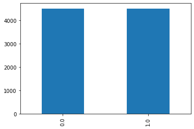

```python
y.value_counts().plot(kind='bar')
```

Thus, now target variable is evenly distributed.

#### F. Again train the same previous model on balanced data. [1 Marks]

```python
from sklearn.linear_model import LogisticRegression

# Fit the model on train
model = LogisticRegression(solver="liblinear")
model.fit(x_train, y_train)
#predict on test
y_predict = model.predict(x_test)


coef_df = pd.DataFrame(model.coef_)
coef_df['intercept'] = model.intercept_

print("Intercept: ",model.intercept_)
print("Coefficients are:")
print(model.coef_)
```

```
Intercept:  [-8.10411994]
Coefficients are:
[[-7.76704090e-02  7.05990843e-02  5.48270080e-02  6.13815631e-01
   2.05839521e-01  1.42444224e+00 -1.38416821e-03 -1.22276937e+00
   4.36636592e+00 -8.60371082e-01 -9.26537588e-01]]
```

#### G. Print evaluation metrics and clearly share differences observed. [2 Marks]

```python
model_score = model.score(x_test, y_test)
print(model_score)
```

```
0.9071111111111111
```

```python
# And some other metrics

print(metrics.classification_report(y_test, y_predict, digits=2))
```

```
              precision    recall  f1-score   support

         0.0       0.93      0.87      0.90      1115
         1.0       0.88      0.94      0.91      1135

    accuracy                           0.91      2250
   macro avg       0.91      0.91      0.91      2250
weighted avg       0.91      0.91      0.91      2250
```

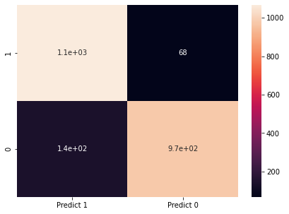

```python
cm=metrics.confusion_matrix(y_test, y_predict, labels=[1, 0])

df_cm = pd.DataFrame(cm, index = [i for i in ["1","0"]],
                  columns = [i for i in ["Predict 1","Predict 0"]])
plt.figure(figsize = (7,5))
sns.heatmap(df_cm, annot=True)
```

The confusion matrix

False Positives (FP): we incorrectly predicted that there is loan on card (a "Type I error") 142 Falsely predict positive Type I error

False Negatives (FN): we incorrectly predicted that there is no loan on card (a "Type II error") 68 Falsely predict negative Type II error

```python
Precision_ln_bal =precision_score(y_test, y_predict, average='weighted')
print("Precision linear reg after balancing:{0:.4f}".format(Precision_ln_bal))
Recall_ln_bal =recall_score(y_test, y_predict, average='weighted')
print("Recall linear reg after balancing:{0:.4f}".format(Recall_ln_bal))
Accuracy_ln_bal =accuracy_score(y_test, y_predict)
print("Accuracy linear reg after balancing:{0:.4f}".format(Accuracy_ln_bal))
# Calculate the AUC
fpr, tpr, _ = metrics.roc_curve(y_test,  y_predict)
auc_logreg = metrics.roc_auc_score(y_test, y_predict)
print("ROCAUC linear reg after balancing:{0:.4f}".format(auc_logreg))
```

```
Precision linear reg after balancing:0.9088
Recall linear reg after balancing:0.9071
Accuracy linear reg after balancing:0.9071
ROCAUC linear reg after balancing:0.9068
```

Thus, after balancing using smote sampling we could see that the accuracy got reduced from 95% to 90%, as this considers the balance in data in the target variable classes

### 4. Performance Improvement: [10 Marks]

#### A. Train a base model each for SVM, KNN. [4 Marks]

## KNN

```python
# Split X and y into training and test set in 75:25 ratio

x_train, x_test, y_train, y_test = train_test_split(x, y, test_size=0.25, random_state=1)

x_train.head()
```

|  | Age | CustomerSince | HighestSpend | HiddenScore | MonthlyAverageSpend | Level | Mortgage | Security | FixedDepositAccount | InternetBanking | CreditCard |
| --- | --- | --- | --- | --- | --- | --- | --- | --- | --- | --- | --- |
| 1736 | 43 | 17 | 32 | 3.0 | 0.500000 | 2.0 | 0 | 0.0 | 0.0 | 1.0 | 0.0 |
| 842 | 44 | 20 | 180 | 2.0 | 7.600000 | 1.0 | 524 | 0.0 | 0.0 | 0.0 | 1.0 |
| 7005 | 54 | 29 | 117 | 3.241856 | 2.773939 | 1.0 | 0 | 1.0 | 1.0 | 0.241856 | 0.0 |
| 3465 | 40 | 16 | 125 | 2.0 | 1.900000 | 1.0 | 0 | 0.0 | 0.0 | 0.0 | 1.0 |
| 3798 | 43 | 19 | 161 | 2.0 | 7.600000 | 1.0 | 464 | 0.0 | 0.0 | 1.0 | 0.0 |

```python
#We can see a lot of 0 entries above
from sklearn.impute import SimpleImputer
rep_0 = SimpleImputer(missing_values=0, strategy="mean")
x_train["CustomerSince"] = rep_0.fit_transform(x_train[["CustomerSince"]]).ravel()
x_train["Mortgage"] = rep_0.fit_transform(x_train[["Mortgage"]]).ravel()
x_train["Age"] = rep_0.fit_transform(x_train[["Age"]]).ravel()
x_train["HighestSpend"] = rep_0.fit_transform(x_train[["HighestSpend"]]).ravel()
x_train["MonthlyAverageSpend"] = rep_0.fit_transform(x_train[["MonthlyAverageSpend"]]).ravel()
x_train.head()
```

|  | Age | CustomerSince | HighestSpend | HiddenScore | MonthlyAverageSpend | Level | Mortgage | Security | FixedDepositAccount | InternetBanking | CreditCard |
| --- | --- | --- | --- | --- | --- | --- | --- | --- | --- | --- | --- |
| 1736 | 43.0 | 17.0 | 32.0 | 3.0 | 0.500000 | 2.0 | 233.797953 | 0.0 | 0.0 | 1.0 | 0.0 |
| 842 | 44.0 | 20.0 | 180.0 | 2.0 | 7.600000 | 1.0 | 524.000000 | 0.0 | 0.0 | 0.0 | 1.0 |
| 7005 | 54.0 | 29.0 | 117.0 | 3.241856 | 2.773939 | 1.0 | 233.797953 | 1.0 | 1.0 | 0.241856 | 0.0 |
| 3465 | 40.0 | 16.0 | 125.0 | 2.0 | 1.900000 | 1.0 | 233.797953 | 0.0 | 0.0 | 0.0 | 1.0 |
| 3798 | 43.0 | 19.0 | 161.0 | 2.0 | 7.600000 | 1.0 | 464.000000 | 0.0 | 0.0 | 1.0 | 0.0 |

```python
knn = KNeighborsClassifier()

# Call Nearest Neighbour algorithm

knn.fit(x_train, y_train)

# For every test data point, predict it's label based on 5 nearest neighbours in this model. The majority class will
# be assigned to the test data point

predicted_labels_y = knn.predict(x_test)
accuracy_score(y_test, predicted_labels_y)
```

```
0.8928888888888888
```

```
Confusion Matrix
```

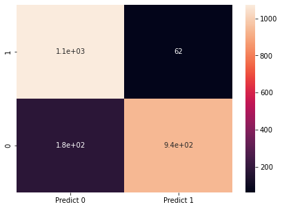

```python
# calculate accuracy measures and confusion matrix
from sklearn import metrics

print("Confusion Matrix")
cm=metrics.confusion_matrix(y_test, predicted_labels_y, labels=[1,0])

df_cm = pd.DataFrame(cm, index = [i for i in [1,0]],
                  columns = [i for i in ["Predict 0","Predict 1"]])
plt.figure(figsize = (7,5))
sns.heatmap(df_cm, annot=True)
```

```python
print("Classification Report")
print(metrics.classification_report(y_test, predicted_labels_y))
```

```
Classification Report
              precision    recall  f1-score   support

         0.0       0.94      0.84      0.89      1115
         1.0       0.86      0.95      0.90      1135

    accuracy                           0.89      2250
   macro avg       0.90      0.89      0.89      2250
weighted avg       0.90      0.89      0.89      2250
```

## SVM

```python
# Split X and y into training and test set in 75:25 ratio

x_train, x_test, y_train, y_test = train_test_split(x, y, test_size=0.25, random_state=1)

x_train.head()
```

|  | Age | CustomerSince | HighestSpend | HiddenScore | MonthlyAverageSpend | Level | Mortgage | Security | FixedDepositAccount | InternetBanking | CreditCard |
| --- | --- | --- | --- | --- | --- | --- | --- | --- | --- | --- | --- |
| 1736 | 43 | 17 | 32 | 3.0 | 0.500000 | 2.0 | 0 | 0.0 | 0.0 | 1.0 | 0.0 |
| 842 | 44 | 20 | 180 | 2.0 | 7.600000 | 1.0 | 524 | 0.0 | 0.0 | 0.0 | 1.0 |
| 7005 | 54 | 29 | 117 | 3.241856 | 2.773939 | 1.0 | 0 | 1.0 | 1.0 | 0.241856 | 0.0 |
| 3465 | 40 | 16 | 125 | 2.0 | 1.900000 | 1.0 | 0 | 0.0 | 0.0 | 0.0 | 1.0 |
| 3798 | 43 | 19 | 161 | 2.0 | 7.600000 | 1.0 | 464 | 0.0 | 0.0 | 1.0 | 0.0 |

```python
#We can see a lot of 0 entries above
from sklearn.impute import SimpleImputer
rep_0 = SimpleImputer(missing_values=0, strategy="mean")
x_train["CustomerSince"] = rep_0.fit_transform(x_train[["CustomerSince"]]).ravel()
x_train["Mortgage"] = rep_0.fit_transform(x_train[["Mortgage"]]).ravel()
x_train["Age"] = rep_0.fit_transform(x_train[["Age"]]).ravel()
x_train["HighestSpend"] = rep_0.fit_transform(x_train[["HighestSpend"]]).ravel()
x_train["MonthlyAverageSpend"] = rep_0.fit_transform(x_train[["MonthlyAverageSpend"]]).ravel()
x_train.head()
```

|  | Age | CustomerSince | HighestSpend | HiddenScore | MonthlyAverageSpend | Level | Mortgage | Security | FixedDepositAccount | InternetBanking | CreditCard |
| --- | --- | --- | --- | --- | --- | --- | --- | --- | --- | --- | --- |
| 1736 | 43.0 | 17.0 | 32.0 | 3.0 | 0.500000 | 2.0 | 233.797953 | 0.0 | 0.0 | 1.0 | 0.0 |
| 842 | 44.0 | 20.0 | 180.0 | 2.0 | 7.600000 | 1.0 | 524.000000 | 0.0 | 0.0 | 0.0 | 1.0 |
| 7005 | 54.0 | 29.0 | 117.0 | 3.241856 | 2.773939 | 1.0 | 233.797953 | 1.0 | 1.0 | 0.241856 | 0.0 |
| 3465 | 40.0 | 16.0 | 125.0 | 2.0 | 1.900000 | 1.0 | 233.797953 | 0.0 | 0.0 | 0.0 | 1.0 |
| 3798 | 43.0 | 19.0 | 161.0 | 2.0 | 7.600000 | 1.0 | 464.000000 | 0.0 | 0.0 | 1.0 | 0.0 |

```python
from sklearn import svm
```

```python
def getAccuracy(testSet, predictions):
	correct = 0
	for x in range(len(testSet)):
		if testSet[x]== predictions[x]:
			correct += 1
	return (correct/float(len(testSet))) * 100.0
```

```python
clf = svm.SVC(gamma=0.025, C=3)

clf.fit(x_train , y_train)

y_pred = clf.predict(x_test)
```

```python
y_test = pd.DataFrame(y_test)
y_test_ar = pd.DataFrame.to_numpy(y_test)
```

```python
getAccuracy(y_test_ar,y_pred)
```

```
65.73333333333333
```

#### B. Tune parameters for each of the models wherever required and finalize a model. [3 Marks]

##### (Optional: Experiment with various Hyperparameters - Research required)

## KNN

```python
# Split X and y into training and test set in 75:25 ratio

x_train, x_test, y_train, y_test = train_test_split(x, y, test_size=0.25, random_state=1)

x_train.head()
```

|  | Age | CustomerSince | HighestSpend | HiddenScore | MonthlyAverageSpend | Level | Mortgage | Security | FixedDepositAccount | InternetBanking | CreditCard |
| --- | --- | --- | --- | --- | --- | --- | --- | --- | --- | --- | --- |
| 1736 | 43 | 17 | 32 | 3.0 | 0.500000 | 2.0 | 0 | 0.0 | 0.0 | 1.0 | 0.0 |
| 842 | 44 | 20 | 180 | 2.0 | 7.600000 | 1.0 | 524 | 0.0 | 0.0 | 0.0 | 1.0 |
| 7005 | 54 | 29 | 117 | 3.241856 | 2.773939 | 1.0 | 0 | 1.0 | 1.0 | 0.241856 | 0.0 |
| 3465 | 40 | 16 | 125 | 2.0 | 1.900000 | 1.0 | 0 | 0.0 | 0.0 | 0.0 | 1.0 |
| 3798 | 43 | 19 | 161 | 2.0 | 7.600000 | 1.0 | 464 | 0.0 | 0.0 | 1.0 | 0.0 |

```python
#We can see a lot of 0 entries above
from sklearn.impute import SimpleImputer
rep_0 = SimpleImputer(missing_values=0, strategy="mean")
x_train["CustomerSince"] = rep_0.fit_transform(x_train[["CustomerSince"]]).ravel()
x_train["Mortgage"] = rep_0.fit_transform(x_train[["Mortgage"]]).ravel()
x_train["Age"] = rep_0.fit_transform(x_train[["Age"]]).ravel()
x_train["HighestSpend"] = rep_0.fit_transform(x_train[["HighestSpend"]]).ravel()
x_train["MonthlyAverageSpend"] = rep_0.fit_transform(x_train[["MonthlyAverageSpend"]]).ravel()
x_train.head()
```

|  | Age | CustomerSince | HighestSpend | HiddenScore | MonthlyAverageSpend | Level | Mortgage | Security | FixedDepositAccount | InternetBanking | CreditCard |
| --- | --- | --- | --- | --- | --- | --- | --- | --- | --- | --- | --- |
| 1736 | 43.0 | 17.0 | 32.0 | 3.0 | 0.500000 | 2.0 | 233.797953 | 0.0 | 0.0 | 1.0 | 0.0 |
| 842 | 44.0 | 20.0 | 180.0 | 2.0 | 7.600000 | 1.0 | 524.000000 | 0.0 | 0.0 | 0.0 | 1.0 |
| 7005 | 54.0 | 29.0 | 117.0 | 3.241856 | 2.773939 | 1.0 | 233.797953 | 1.0 | 1.0 | 0.241856 | 0.0 |
| 3465 | 40.0 | 16.0 | 125.0 | 2.0 | 1.900000 | 1.0 | 233.797953 | 0.0 | 0.0 | 0.0 | 1.0 |
| 3798 | 43.0 | 19.0 | 161.0 | 2.0 | 7.600000 | 1.0 | 464.000000 | 0.0 | 0.0 | 1.0 | 0.0 |

```python
# creating odd list of K for KNN
myList = list(range(1,20))

# subsetting just the odd ones
neighbors = list(filter(lambda x: x % 2 != 0, myList))

# empty list that will hold accuracy scores
ac_scores = []

# perform accuracy metrics for values from 1,3,5....19
for k in neighbors:
    knn = KNeighborsClassifier(n_neighbors=k)
    knn.fit(x_train, y_train)
    # predict the response
    y_pred = knn.predict(x_test)
    # evaluate accuracy
    scores = accuracy_score(y_test, y_pred)
    ac_scores.append(scores)

# changing to misclassification error
MSE = [1 - x for x in ac_scores]

# determining best k
optimal_k = neighbors[MSE.index(min(MSE))]
print("The optimal number of neighbors is %d" % optimal_k)
```

```
The optimal number of neighbors is 5
```

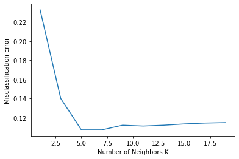

```python
#Plot misclassification error vs k (with k value on X-axis) using matplotlib.

import matplotlib.pyplot as plt
# plot misclassification error vs k
plt.plot(neighbors, MSE)
plt.xlabel('Number of Neighbors K')
plt.ylabel('Misclassification Error')
plt.show()
```

When the number of neighbors is 5 there is min error

```python
# Split X and y into training and test set in 80:20 ratio
x_train, x_test, y_train, y_test = train_test_split(x, y, test_size=0.25, random_state=1)

rep_0 = SimpleImputer(missing_values=0, strategy="mean")
x_train["CustomerSince"] = rep_0.fit_transform(x_train[["CustomerSince"]]).ravel()
x_train["Mortgage"] = rep_0.fit_transform(x_train[["Mortgage"]]).ravel()
x_train["Age"] = rep_0.fit_transform(x_train[["Age"]]).ravel()
x_train["HighestSpend"] = rep_0.fit_transform(x_train[["HighestSpend"]]).ravel()
x_train["MonthlyAverageSpend"] = rep_0.fit_transform(x_train[["MonthlyAverageSpend"]]).ravel()

NNH = KNeighborsClassifier(n_neighbors= 5)

# Call Nearest Neighbour algorithm
NNH.fit(x_train, y_train)

# For every test data point, predict it's label based on 1 nearest neighbours in this model. The majority class will # be assigned to the test data point
predicted_labels = NNH.predict(x_test)
NNH.score(x_test, y_test)
```

```
0.8928888888888888
```

```
Confusion Matrix
```

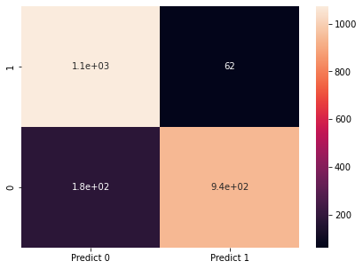

```python
# calculate accuracy measures and confusion matrix
from sklearn import metrics

print("Confusion Matrix")
cm=metrics.confusion_matrix(y_test, predicted_labels, labels=[1,0])

df_cm = pd.DataFrame(cm, index = [i for i in [1,0]],
                  columns = [i for i in ["Predict 0","Predict 1"]])
plt.figure(figsize = (7,5))
sns.heatmap(df_cm, annot=True)
```

```python
print("Classification Report")
print(metrics.classification_report(y_test, predicted_labels))
```

```
Classification Report
              precision    recall  f1-score   support

         0.0       0.94      0.84      0.89      1115
         1.0       0.86      0.95      0.90      1135

    accuracy                           0.89      2250
   macro avg       0.90      0.89      0.89      2250
weighted avg       0.90      0.89      0.89      2250
```

```python
Precision_knn_bal =precision_score(y_test, predicted_labels, average='weighted')
print("Precision knn after balancing:{0:.4f}".format(Precision_knn_bal))
Recall_knn_bal =recall_score(y_test, predicted_labels, average='weighted')
print("Recall knn after balancing:{0:.4f}".format(Recall_knn_bal))
Accuracy_knn_bal =accuracy_score(y_test, predicted_labels)
print("Accuracy knn after balancing:{0:.4f}".format(Accuracy_knn_bal))
```

```
Precision knn after balancing:0.8971
Recall knn after balancing:0.8929
Accuracy knn after balancing:0.8929
```

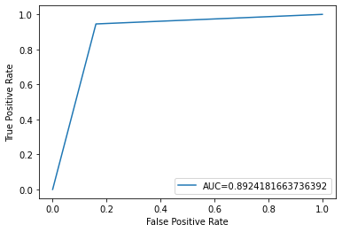

```python
# Calculate the AUC
fpr, tpr, _ = metrics.roc_curve(y_test,  predicted_labels)
auc_knn = metrics.roc_auc_score(y_test, predicted_labels)

#create ROC curve
plt.plot(fpr,tpr,label="AUC="+str(auc_knn))
plt.ylabel('True Positive Rate')
plt.xlabel('False Positive Rate')
plt.legend(loc=4)
plt.show()
```

The more that the curve hugs the top left corner of the plot, the better the model does at classifying the data into categories.

As we can see from the plot above, this KNN model does a pretty better job of classifying the data into categories.

To quantify this, we can calculate the AUC – area under the curve – which tells us how much of the plot is located under the curve.

The closer AUC is to 1, the better the model. A model with an AUC equal to 0.5 is no better than a model that makes random classifications.

Thus, AUC = 0.89 is closer to 1, which proves that this model is a better one for this case.

## SVM

```python
from sklearn.model_selection import GridSearchCV
from sklearn.datasets import make_classification
from sklearn.ensemble import RandomForestClassifier
```

```python
#Create a dictionary of possible parameters
params_grid = {'C': [0.001, 0.01, 0.1, 1, 10, 100],
          'gamma': [0.0001, 0.001, 0.01, 0.1],
          'kernel':['linear','rbf'] }

#Create the GridSearchCV object
grid_clf = GridSearchCV(svm.SVC(class_weight='balanced'), params_grid)

#Fit the data with the best possible parameters
grid_clf = clf.fit(x_train, y_train)

#Print the best estimator with it's parameters
grid_clf
```

```
SVC(C=3, gamma=0.025)
```

```python
clf = svm.SVC(gamma=0.025, C=3)
clf.fit(x_train , y_train)

y_pred_svm = clf.predict(x_test)

getAccuracy(y_test_ar , y_pred_svm)
```

```
65.73333333333333
```

```python
Precision_svm_bal =precision_score(y_test_ar, y_pred_svm, average='weighted')
print("Precision svm after balancing:{0:.4f}".format(Precision_svm_bal))
Recall_svm_bal =recall_score(y_test_ar, y_pred_svm, average='weighted')
print("Recall svm after balancing:{0:.4f}".format(Recall_svm_bal))
Accuracy_svm_bal =accuracy_score(y_test_ar, y_pred_svm)
print("Accuracy svm after balancing:{0:.4f}".format(Accuracy_svm_bal))
```

```
Precision svm after balancing:0.7848
Recall svm after balancing:0.6573
Accuracy svm after balancing:0.6573
```

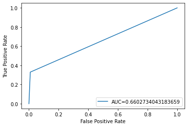

```python
# Calculate the AUC
fpr, tpr, _ = metrics.roc_curve(y_test,  y_pred_svm)
auc_svm = metrics.roc_auc_score(y_test, y_pred_svm)

#create ROC curve
plt.plot(fpr,tpr,label="AUC="+str(auc_svm))
plt.ylabel('True Positive Rate')
plt.xlabel('False Positive Rate')
plt.legend(loc=4)
plt.show()
```

The more that the curve hugs the top left corner of the plot, the better the model does at classifying the data into categories.

As we can see from the plot above, this SVM model does a pretty poor job of classifying the data into categories.

To quantify this, we can calculate the AUC – area under the curve – which tells us how much of the plot is located under the curve.

The closer AUC is to 1, the better the model. A model with an AUC equal to 0.5 is no better than a model that makes random classifications.

Thus, AUC = 0.66 is closer to 0.5, which proves that this model is a poor performing for this case.

#### C. Print evaluation metrics for final model. [1 Marks]

Logistic Regression is the best model compared to SVM and KNN for this case with 90% accuracy.

```python
from sklearn.linear_model import LogisticRegression

# Fit the model on train
model = LogisticRegression(solver="liblinear")
model.fit(x_train, y_train)
#predict on test
y_predict = model.predict(x_test)


coef_df = pd.DataFrame(model.coef_)
coef_df['intercept'] = model.intercept_

print("Intercept: ",model.intercept_)
print("Coefficients are:")
print(model.coef_)
```

```
Intercept:  [-8.10411994]
Coefficients are:
[[-7.76704090e-02  7.05990843e-02  5.48270080e-02  6.13815631e-01
   2.05839521e-01  1.42444224e+00 -1.38416821e-03 -1.22276937e+00
   4.36636592e+00 -8.60371082e-01 -9.26537588e-01]]
```

```python
model_score = model.score(x_test, y_test)
print(model_score)
```

```
0.9071111111111111
```

```python
# And some other metrics

print(metrics.classification_report(y_test, y_predict, digits=2))
```

```
              precision    recall  f1-score   support

         0.0       0.93      0.87      0.90      1115
         1.0       0.88      0.94      0.91      1135

    accuracy                           0.91      2250
   macro avg       0.91      0.91      0.91      2250
weighted avg       0.91      0.91      0.91      2250
```

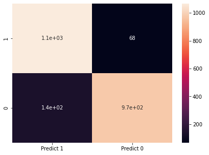

```python
cm=metrics.confusion_matrix(y_test, y_predict, labels=[1, 0])

df_cm = pd.DataFrame(cm, index = [i for i in ["1","0"]],
                  columns = [i for i in ["Predict 1","Predict 0"]])
plt.figure(figsize = (7,5))
sns.heatmap(df_cm, annot=True)
```

The confusion matrix

True Negatives (TN): we correctly predicted that there is no loan on card 970

False Positives (FP): we incorrectly predicted that there is loan on card (a "Type I error") 140 Falsely predict positive Type I error

False Negatives (FN): we incorrectly predicted that there is no loan on card (a "Type II error") 68 Falsely predict negative Type II error

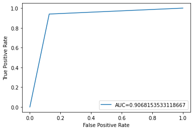

```python
# Calculate the AUC
fpr, tpr, _ = metrics.roc_curve(y_test,  y_predict)
auc_logreg = metrics.roc_auc_score(y_test, y_predict)

#create ROC curve
plt.plot(fpr,tpr,label="AUC="+str(auc_logreg))
plt.ylabel('True Positive Rate')
plt.xlabel('False Positive Rate')
plt.legend(loc=4)
plt.show()
```

The more that the curve hugs the top left corner of the plot, the better the model does at classifying the data into categories.

As we can see from the plot above, this logistic regression model does a pretty better job of classifying the data into categories.

To quantify this, we can calculate the AUC – area under the curve – which tells us how much of the plot is located under the curve.

The closer AUC is to 1, the better the model. A model with an AUC equal to 0.5 is no better than a model that makes random classifications.

Thus, AUC = 0.90 is closer to 1, which proves that this model is the best one for this case.

#### D. Share improvement achieved from base model to final model. [2 Marks]

Base Model - Logistic Reg before balancing - Accuracy, Precision and Recall Details

```python
print("Precision before balancing:{0:.4f}".format(Precision_b4_bal))
print("Recall before balancing:{0:.4f}".format(Recall_b4_bal))
print("Accuracy before balancing:{0:.4f}".format(Accuracy_b4_bal))
print("ROCAUC before balancing:{0:.4f}".format(auc_b4_bal))
```

```
Precision before balancing:0.9426
Recall before balancing:0.9462
Accuracy before balancing:0.9462
ROCAUC before balancing:0.7886
```

KNN with optimum Hyperparameters - Accuracy, Precision and Recall

```python
print("Precision knn after balancing:{0:.4f}".format(Precision_knn_bal))
print("Recall knn after balancing:{0:.4f}".format(Recall_knn_bal))
print("Accuracy knn after balancing:{0:.4f}".format(Accuracy_knn_bal))
print("ROCAUC knn after balancing:{0:.4f}".format(auc_knn))
```

```
Precision knn after balancing:0.8971
Recall knn after balancing:0.8929
Accuracy knn after balancing:0.8929
ROCAUC knn after balancing:0.8924
```

```python
print("Precision svm after balancing:{0:.4f}".format(Precision_svm_bal))
print("Recall svm after balancing:{0:.4f}".format(Recall_svm_bal))
print("Accuracy svm after balancing:{0:.4f}".format(Accuracy_svm_bal))
print("ROCAUC svm after balancing:{0:.4f}".format(auc_svm))
```

```
Precision svm after balancing:0.7848
Recall svm after balancing:0.6573
Accuracy svm after balancing:0.6573
ROCAUC svm after balancing:0.6603
```

Final Model - Logistic Reg after balancing Accuracy, Precision and Recall

```python
print("Precision Logistic reg after balancing:{0:.4f}".format(Precision_ln_bal))
print("Recall Logistic reg after balancing:{0:.4f}".format(Recall_ln_bal))
print("Accuracy Logistic reg after balancing:{0:.4f}".format(Accuracy_ln_bal))
print("ROCAUC Logistic reg after balancing:{0:.4f}".format(auc_logreg))
```

```
Precision Logistic reg after balancing:0.9088
Recall Logistic reg after balancing:0.9071
Accuracy Logistic reg after balancing:0.9071
ROCAUC Logistic reg after balancing:0.9068
```

Logistic regression is the best method in this case because the dependant variable LoanOnCard is binary.

SVM is suitable in cases where the number of features and number of training data is very large(in millions) (or) when the sparsity in the problem is very high - which is not the case here.

KNN is best suitable for multiclass classification. That is if the data contains more than two lables or categories then KNN can be the suitable algorithm. In our case we only have a dependant variable "LoanOnCard" with only 2 possible values either 0 or 1.

Thus, this is the reason for Logistic regression giving better accuracy than the other models like KNN, SVM.